# Introduction to Nonlinear Estimation

73-374 Econometrics II

## Today

- Nonlinear estimators
- Nonlinear Least Squares Regression
- Principles: consistency

## Nonlinear Estimation

- Many models have no convenient linear representation
- Sometimes we know or believe our data have a particular nonlinear structure
  - Want to exploit this for better estimation and inference
- Simple example: instead of linear regression model

$$Y=\beta_0+\beta_1X_1 +\beta_2X_2+\ldots+\beta_kX_k + u$$

- We may believe in **nonlinear regression** model

$$Y=f(X,\theta) +u$$

- Here, $f(X,\theta)$ is *nonlinear* function of some parameters $\theta$
- Requires applying more general principles for estimation

## Examples

- $Y$ might take on restricted set of values
  - e.g., 0 or 1, or non-negative real numbers, non-negative integers
  - Linear regression model may predict values of $Y$ which are not logically possible
  - Nonlinear models can enforce these restrictions
- We may care about features of data not represented by conditional expectation
  - Conditional probabilities, variances, or other moments
- We may care about conditional expectation function, but believe it is nonlinear function of parameters
  - Ex: $E[Y|X]=\beta_1exp(\gamma_1X_1) +\beta_2 exp(\gamma_2X_2)$, neither $\beta$ nor $\gamma$ known
  - This is nonlinear regression model
  - Focus only on this today, introduce other models later

## Principles

- In general a **model** is a description of the behavior of some **variables** in terms of some (possibly unknown) numbers called **parameters**
- For any set of parameters, the model produces some implications for the distribution of data
- Would like to use these implications to produce estimators of the parameters
- Recall we showed that OLS could be justified by any of several related principles
  - Empirical Risk Minimization
  - Method of moments
  - Maximum likelihood
- All of these principles can be used to find estimators for nonlinear models also

## Empirical Risk Minimization

- Find best predictor of $Y$ among functions $f(X,\theta)$ with parameters $\theta\in\Theta$
- Measure “best” by **loss function** $\ell(Y,f(X))$
  - E.g. $(Y-f(X,\theta))^2$ or $|Y-f(X,\theta)|$ (for real Y) or $-Y\log(f(X,\theta)) - (1-Y)\log(1-f(X,\theta))$ for binary $Y$
- **Risk** is average loss over the distribution of data $E[\ell(Y,f(X,\theta))]$
- Best predictor is the $\theta$ that makes this smallest $\theta_{0}=\underset{\theta\in\Theta}{\arg\min}E[\ell(Y,f(X,\theta))]$
- Don’t know risk, but can approximate it by **empirical risk** $\frac{1}{n}\sum_{i=1}^{n}\ell(Y_i,f(X_i))$
- **Empirical risk minimizer** is
  $$\widehat{\theta}_{0}=\underset{\theta\in\Theta}{\arg\min}\frac{1}{n}\sum_{i=1}^{n}[\ell(Y_i,f(X_i,\theta))]$$
- No need for $f(X,\theta)$ to be just linear functions

## Maximum Likelihood

- Sometimes model specifies entire joint (or at least conditional) distribution of the data, called **likelihood**
- $(Y,X)\sim p(Y,X,\theta)$ or $p(Y|X;\theta)p(X)$
- Fisher had idea that choosing $\theta$ under which observed data set is most probable would give good estimate of parameter for distribution that actually did generate the data
- $(Y_i,X_i)$ iid means joint distribution is product of $p(.)$
- Taking log turns this into sum but doesn’t change arg max
  $$\widehat{\theta}_{MLE}=\underset{\theta\in\Theta}{\arg\max}(\sum_{i=1}^{n}log(p(Y_i|X_i,\theta)))$$
- Likelihood for nonlinear regression with normal errors gives
  $$p(Y|X,\theta)=\frac{1}{\sqrt{2\pi\sigma^2}}\exp(-(Y-f(X,\theta))^2/2\sigma^2)$$
  $$\widehat{\theta}_{MLE}=\underset{\theta\in\Theta}{\arg\max}(\sum_{i=1}^{n}-(Y-f(X,\theta))^2)$$

## Method of Moments

- Model may imply that expectations of certain functions $g(Y,X,\theta)$ satisfy $E[g(Y,X,\theta)]=0$ when $\theta=\theta_0$
- E.g. $Y=f(X,\theta_0)+u$ with $E[u|X]=0$ gives

$$E[(Y-f(X,\theta_0))t(X)]=0$$

- for any functions $t(X)$ of $X$ (by def of conditional expectation)
- If this is *only* true for $\theta=\theta_0$, we say that these moments *identify* $\theta$
- Can solve nonlinear system of equations for $\theta$ that makes moment equations true
- This must be $\theta_0$
- To estimate, replace $E$ by $\frac{1}{n}\sum_{i=1}^{n}$
- Estimate $\widehat{\theta}$ is solution to approximate system
  $$\frac{1}{n}\sum_{i=1}^{n}g(Y,X,\widehat{\theta})=0$$

## Optimization Estimators and Method of moments

- Can usually represent ERM or MLE by method of moments
- Optimum given by solution of first order conditions
  - Set derivative to 0
- $\theta_0=\underset{\theta\in\Theta}{\arg\min}E[\ell(Y,f(X,\theta))]$ requires
  $$0=\frac{\partial}{\partial \theta}E[\ell(Y,f(X,\theta))]=E[\frac{\partial}{\partial f}\ell(Y,f(X,\theta))\frac{\partial}{\partial \theta}f(X,\theta)]$$
- In NLLS case, this gives
  $$E[(Y-f(X,\theta))\frac{\partial}{\partial \theta}f(X,\theta)]=0$$
- $\theta$ is a vector of k parameters
  - System of $k$ equations in $k$ unknowns
- May or may not have unique solution
- In OLS case, unique solution condition known
  - “no multicollinearity”
- For nonlinear estimators, analogous “unique solution” condition needed, but usually hard to express explicitly

## Nonlinear Regression

- Nonlinear least squares (NLLS) is special case of each method
- Handy when model says a conditional expectation function takes a particular nonlinear form
- NLLS, along with more general procedures (method of moments, MLE), often used in “structural” estimation of economic models
  - Derive form of nonlinear relationship from model of individual and equilibrium behavior
  - Means form of estimator looks different in each case

## Doing more with linearity

- Note that OLS can handle nonlinear CEF
  - Use transformations of $X$ or $Y$
- But must search over class of linear combinations of nonlinear transformations
- You can match almost anything by including a high enough order polynomial
- $X=(1,x,x^2,x^3,...,x^k)$
- But for some functions you may need a really big $k$
  - Maybe as big as number of data points
- Standard OLS limit theory *not* applicable
- Might instead choose some other class of transformations
  - Piecewise polynomial (spline), or other exotic functions
- Feasible and useful, will discuss more next week
- But if you know you are in a certain nonlinear class, can use way fewer parameters by NLLS

## Shared Principles

- In terms of model formulation and interpretation, nonlinear least squares $Y=f(X,\theta)+u$ similar to OLS
- Can also find $\theta_0$ such that $f(X,\theta_0)$ gives the best predictor in the nonlinear class of $Y$ given $X$
- If the CEF correctly specified, $E[u|X]=0$, $f(x,\theta_0)$ gives it
- For causal interpretation, need exogeneity condition for structural equation
  - Can use NLLS to find CEF in adjustment formula
  - Exact same conditions (backdoor criterion, etc) apply

## Numerical Optimization

- Parameter value solving minimization equation/nonlinear system not always available in closed form
- Need to calculate optimum numerically
- Many algorithms exist to minimize functions numerically
- Basic idea:
  - Start at some point,
  - Move “downhill” in direction of steepest descent (gradient)
  - Stop when you can’t move any further
- Works so long as function is convex:
  - Bowl shape means moving down always gets you to bottom
  - Problems if there are hills, ridges
- Many details: how far to move each step, how many, etc
- Standard software uses reasonable defaults

## Simulation using nls command

```r
# Generate some data from a nonlinear model
a0<-2
b0<-0.5
x<-5*runif(50)
y<-a0*exp(b0*x)+rnorm(50) #Include normal noise
#Estimate correctly specified model
#Start minimization going downhill from some
#reasonable guess for parameter values
model<-nls(formula=y~a*exp(b*x), start=list(a=1,b=1))
```

## Example: Results (code)

```r
(model)
```

## Example: Results

```
## Nonlinear regression model
##   model: y ~ a * exp(b * x)
##    data: parent.frame()
##      a      b
## 2.1253 0.4843
##  residual sum-of-squares: 43.49
##
## Number of iterations to convergence: 6
## Achieved convergence tolerance: 1.719e-07
```

## Graph

```r
#Generate points to plot predictions
xn<-seq(0,5,length=1000)
ee<-predict(model,list(x=xn)) #Predicted y
plot(x,y,xlab="x",ylab="y",
     main="Nonlinear Least Squares Fit")
lines(xn,ee,lty=2,col="blue")
```

## Graph

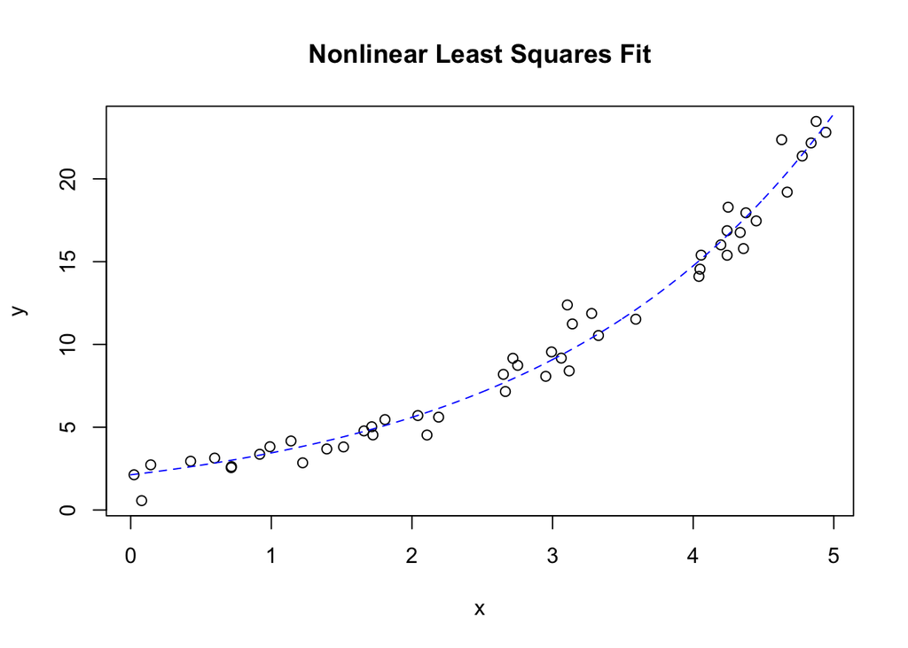

## Consistency: Assumptions

- Suppose true parameter $\theta_0$ satisfies
  $$\theta_0=\underset{\theta\in\Theta}{\arg\min}Q(\theta)$$
- Contains ERM, (negative of) MLE, can do method of moments
- Consider general **extremum estimator** expressed as
  $$\widehat{\theta}=\underset{\theta\in\Theta}{\arg\min}\widehat{Q}(\theta)$$
- $\widehat{Q}$ is some approximation of $Q(\theta)$
- Consistency $Pr(|\widehat{\theta}-\theta_0|>\epsilon)\rightarrow 0$ follows under two conditions
- **Identification**: $\theta_0$ strictly minimizes $Q$
  - $\underset{|\theta-\theta_0|>\epsilon}{\inf}Q(\theta)>Q(\theta_0)$ for all $\epsilon$
  - Any other point must be strictly larger
- **Uniform convergence** of $\widehat{Q}(\theta)$ to $Q(\theta)$
  - $\underset{\theta\in\Theta}{\sup}|\widehat{Q}(\theta)-Q(\theta)|\overset{p}{\rightarrow}0$
  - Approximate objective is close to true objective at all $\theta$, with high probability

## Identification condition: Interpretation

- Identification condition
  - $\underset{|\theta-\theta_0|>\epsilon}{\inf}Q(\theta)>Q(\theta_0)$ for all $\epsilon$
- Means there is a single value that minimizes risk/solves system of equations
  - Not 2, not all along a continuum
  - Rules out multicollinearity, other cases where multiple parameters solve system
- In NLLS
  $$Q(\theta)=E[(Y-f(X,\theta))^2]=E[(f(X,\theta_0)-f(X,\theta)+u)^2]$$
  $$=E[(f(X,\theta_0)-f(X,\theta))^2]+E[u^2]\geq E[u^2]=Q(\theta_0)$$
- $Q(\theta)>Q(\theta_0)$ for $\theta\neq\theta_0$ so long as $f(X,\theta_0)\neq f(X,\theta)$ with positive probability
- Only an issue if two parameters give same $f$

## Uniformity: interpretation

$$\underset{\theta\in\Theta}{\sup}|\widehat{Q}(\theta)-Q(\theta)|\overset{p}{\rightarrow}0$$

- What we want to show is that minimizer of approximately Q is approximately minimizer of Q
- This works so long as $\widehat{Q}$ close enough that no point dips down far enough by random chance to be below true minimum
- Since $\widehat{Q}(\theta)$ is sample average, close at any point by law of large numbers
- Uniformity holds if $\Theta$ not SO big that you can always find some point which fits anything
- E.g., if you allow arbitrary polynomial, can always fit some polynomial to match n points
- In general, if you stop at fixed finite # of parameters smaller than sample size, this always holds

## Neural Networks

- Useful nonlinear functions for regression applications
- Repeatedly compose sums of noninear functions and sums of linear functions
- Single “neuron”: take $k\times 1$ vector $X$ to scalar
  $$f_{j}(b_{0j}+b_{1j}x_1+b_{2j}x_2+\ldots+b_{kj}x_k)$$
- $f_j(u)$ is a fixed nonlinear function
  - E.g. $max(u,0)$ or $tanh(u)$ or $\frac{exp(u)}{1+exp(u)}$
- A layer takes a sum of neurons: $F^{(1)}=\sum_{j=1}^{J}b^{(1)}_{j}f_j(X)$
- Parameters are the $J\times K+1$ coefficients $b$
- Can apply single layer function to inputs which are outputs of another layer, and so on
  - $Y=F^{(L)}(... F^{(2)}( F^{(1)}(X))))$
  - “Deep” Neural network

## Neural Network Modeling

- Many choices when defining the function
  - What nonlinearity, how many layers, how big is $J$ in each, etc
- Can represent just about any relationship, no matter how complicated (Hornik et al 1989)
- Nonconvex: minimize by mix of moving downhill, picking random points/directions
- Great results for applications with big $k$, complicated function
  - IF data set is huge
- E.g., $X$ is $k$ pixel photograph, k very big
  - y is indicator = 1 if photo contains a dog
  - Millions of photos of dogs on internet,
  - Can get accurate prediction with some nonlinear function

## Next Time

- Inference for nonlinear models
- More NLLS

## Consistency: Proof (supplemental: graphical version on board)

- By identification, there is some $\delta$ such that

$$Pr(|\widehat{\theta}-\theta_0|>\epsilon)<Pr(Q(\widehat{\theta})-Q(\theta_0)>\delta)$$
$$=Pr(Q(\widehat{\theta})-\widehat{Q}(\widehat{\theta})+\widehat{Q}(\widehat{\theta})-Q(\theta_0)>\delta)$$
$$\leq Pr(Q(\widehat{\theta})-\widehat{Q}(\widehat{\theta})+\widehat{Q}(\theta_0)-Q(\theta_0)>\delta)$$

- Since $\widehat{\theta}$ minimizes $\widehat{Q}()$

$$\leq Pr(2\underset{\theta\in\Theta}{\sup}|\widehat{Q}(\theta)-Q(\theta)|>\delta)\rightarrow 0$$

- By uniform convergence